# Biostatistics 140.623

Biostatistics 140.623

Problem Set 2

Biostatistics 140.623 Third Term, 2017-2018 Problem Set 2 (with R) Survival in Primary Biliary Cirrhosis Learning Objectives: Students who successfully complete this section will be able to: - To evaluate whether the drug DPCA prolongs life in patients. - To identify baseline characteristics of patients which predict longer survival. - Analyze the survival time data (without grouping) by the Kaplan-Meier estimate of the survival function, the log- rank statistic, and Cox proportional hazards model. - Check the estimated model for its consistency with the observed data; in particular, check the proportional hazards assumption using the complementary log-log plot of the estimated survival function. - Summarize the findings for public health readers and document and archive the steps of the statistical analysis by creating a script file in R.

Data Set: Between January 1974 and May 1984, a double-blinded randomized trial on patients with primary biliary cirrhosis (PBC) of the liver was conducted at the Mayo clinic. A total of 312 patients were randomized to either receive the drug D-penicillin (DPCA) or a placebo. Patients were followed until they died from PBC or until censoring, either because of administrative censoring (withdrawn alive at end of study), death not attributable to PBC, liver transplantation, or loss to follow-up. At baseline, a large number of clinical, biochemical, serological and histologic measurements were recorded on each patient. This data set is a subset of the original data, and includes information on each patient’s time to death or censoring, treatment, age, gender, serum bilirubin, and histologic disease stage (1-4). The variables included in this dataset include: case: unique patient ID number sex: 0 = male, 1 = female (coded as “Female” and “Male” in the csv file rather than 0/1) drug: 0 = placebo, 1 = DPCA bil : serum bilirubin in mg/dl survyr: time (in years) to death or censoring death: indicator = 1 if patient died, 0 if censored ageyr: age in years [continuous variable] histo: histologic disease stage (1 – 4) [categorical variable] agecat: age categories, coded as “< 45 yrs”, “45 – 55 yrs”, and “>= 55 yrs” Also included in the data set for your possible use are the following indicator (dummy) variables:

Age Indicators (indicator versions of agecat): agegr_2: 1 if patient is 45-55 years old, 0 otherwise agegr_3: 1 if patient is >= 55 years old, 0 otherwise Histologic Stage Indicators: hstage2: 1 if patient is in Stage 2, 0 otherwise hstage3: 1 if patient is in Stage 3, 0 otherwise hstage4: 1 if patient is in Stage 4, 0 otherwise The data are stored in the csv data set pbctrial.csv, which may be downloaded from the course website. Methods: Use the data set described above and the appropriate statistical analyses to address the specific learning objectives listed on the first page. Hints: The hints shown below are based on a dataset with the name pbcData, read in with the following code. In the following list of commands, if you want to look at differences by other variables than drug, you should change the variable name! Create a new .R file to type/run your commands so that you will have a record of your analysis.

```r
library(readr)
pbcData = read_csv("pbctrial.csv")
```

1. Explore the data using descriptive statistics: table() prop.table() summary() etc

```r
dim(pbcData)
```

```
## [1] 312  18
```

```r
str(pbcData)
```

[output not shown]

```r
summary(pbcData)
```

```
##       case             drug            sex                 bil
##  Min.   :  1.00   Min.   :0.0000   Length:312         Min.   : 0.300
##  1st Qu.: 78.75   1st Qu.:0.0000   Class :character   1st Qu.: 0.800
##  Median :156.50   Median :1.0000   Mode  :character   Median : 1.350
##  Mean   :156.50   Mean   :0.5064                      Mean   : 3.256
##  3rd Qu.:234.25   3rd Qu.:1.0000                      3rd Qu.: 3.425
##  Max.   :312.00   Max.   :1.0000                      Max.   :28.000
##      histo           death            survyr             _st
##  Min.   :1.000   Min.   :0.0000   Min.   : 0.1123   Min.   :1
##  1st Qu.:2.000   1st Qu.:0.0000   1st Qu.: 3.2630   1st Qu.:1
##  Median :3.000   Median :0.0000   Median : 5.0397   Median :1
##  Mean   :3.032   Mean   :0.4006   Mean   : 5.4969   Mean   :1
##  3rd Qu.:4.000   3rd Qu.:1.0000   3rd Qu.: 7.3897   3rd Qu.:1
##  Max.   :4.000   Max.   :1.0000   Max.   :12.4822   Max.   :1
##        _d               _t               _t0        ageyr
##  Min.   :0.0000   Min.   : 0.1123   Min.   :0   Min.   :26.30
##  1st Qu.:0.0000   1st Qu.: 3.2630   1st Qu.:0   1st Qu.:42.27
##  Median :0.0000   Median : 5.0397   Median :0   Median :49.83
##  Mean   :0.4006   Mean   : 5.4969   Mean   :0   Mean   :50.05
##  3rd Qu.:1.0000   3rd Qu.: 7.3897   3rd Qu.:0   3rd Qu.:56.75
##  Max.   :1.0000   Max.   :12.4822   Max.   :0   Max.   :78.49
##     agecat             agegr_2          agegr_3          hstage2
##  Length:312         Min.   :0.0000   Min.   :0.0000   Min.   :0.0000
##  Class :character   1st Qu.:0.0000   1st Qu.:0.0000   1st Qu.:0.0000
##  Mode  :character   Median :0.0000   Median :0.0000   Median :0.0000
##                     Mean   :0.3237   Mean   :0.3365   Mean   :0.2147
##                     3rd Qu.:1.0000   3rd Qu.:1.0000   3rd Qu.:0.0000
##                     Max.   :1.0000   Max.   :1.0000   Max.   :1.0000
##     hstage3          hstage4
##  Min.   :0.0000   Min.   :0.0000
##  1st Qu.:0.0000   1st Qu.:0.0000
##  Median :0.0000   Median :0.0000
##  Mean   :0.3846   Mean   :0.3494
##  3rd Qu.:1.0000   3rd Qu.:1.0000
##  Max.   :1.0000   Max.   :1.0000
```

2. Define a survival object, defining the time variable (survyr) and the event (death == 1). To do this, you must first install and load the “survival” package:

```r
# install.packages("survival")
library(survival)
```

## only run this the first time

```r
pbcData$SurvObj = with(pbcData, Surv(survyr, death == 1))
```

3. Explore differences in time to death by different baseline variables using graphs and complementary log-log plots.

```r
# estimate survival curves for entire sample
km.overall = survfit(SurvObj ~ 1, data = pbcData,
type="kaplan-meier", conf.type="log-log")
km.overall
```

```
## Call: survfit(formula = SurvObj ~ 1, data = pbcData, type = "kaplan-meier",
##     conf.type = "log-log")
##
##       n  events  median 0.95LCL 0.95UCL
##  312.00  125.00    9.30    8.45   10.52
```

```r
summary(km.overall)
```

```
## Call: survfit(formula = SurvObj ~ 1, data = pbcData, type = "kaplan-meier",
##     conf.type = "log-log")
##
##    time n.risk n.event survival std.err lower 95% CI upper 95% CI
##   0.112    312       1    0.997 0.00320        0.977        1.000
##   0.140    311       1    0.994 0.00452        0.975        0.998
##   0.195    310       1    0.990 0.00552        0.970        0.997
##   0.211    309       1    0.987 0.00637        0.966        0.995
##   0.301    308       1    0.984 0.00711        0.962        0.993
##   0.356    307       1    0.981 0.00778        0.958        0.991
##   0.359    306       1    0.978 0.00838        0.954        0.989
##   0.384    305       1    0.974 0.00895        0.949        0.987
##   0.490    304       1    0.971 0.00948        0.945        0.985
##   0.510    303       1    0.968 0.00997        0.941        0.983
##   0.523    302       1    0.965 0.01044        0.937        0.980
##   0.542    301       1    0.962 0.01089        0.933        0.978
##   0.567    300       1    0.958 0.01131        0.929        0.976
##   0.592    299       1    0.955 0.01172        0.925        0.973
##   0.611    298       1    0.952 0.01211        0.922        0.971
##   0.723    297       2    0.946 0.01285        0.914        0.966
##   0.833    295       1    0.942 0.01320        0.910        0.963
##   0.879    294       1    0.939 0.01354        0.906        0.961
##   0.893    293       1    0.936 0.01387        0.902        0.958
##   0.915    292       1    0.933 0.01418        0.899        0.956
##   0.953    291       1    0.929 0.01449        0.895        0.953
##   1.063    290       1    0.926 0.01479        0.891        0.950
##   1.096    289       1    0.923 0.01509        0.887        0.948
##   1.260    288       1    0.920 0.01537        0.884        0.945
##   1.411    287       1    0.917 0.01565        0.880        0.942
##   1.504    285       1    0.913 0.01592        0.876        0.940
##   1.512    284       1    0.910 0.01619        0.873        0.937
##   1.636    283       1    0.907 0.01644        0.869        0.934
##   1.674    282       1    0.904 0.01670        0.865        0.932
##   1.844    281       1    0.901 0.01695        0.862        0.929
##   1.901    280       1    0.897 0.01719        0.858        0.926
##   1.940    279       1    0.894 0.01742        0.854        0.924
##   2.008    277       1    0.891 0.01766        0.851        0.921
##   2.055    275       1    0.888 0.01789        0.847        0.918
##   2.088    274       1    0.884 0.01811        0.843        0.915
##   2.107    273       1    0.881 0.01833        0.840        0.912
```

[output cut: 71 more lines]

```
##   8.685     53       1    0.543 0.03646        0.469        0.612
##   8.827     52       1    0.533 0.03723        0.457        0.603
##   8.888     50       1    0.522 0.03798        0.445        0.594
##   8.992     48       1    0.511 0.03872        0.433        0.584
##   9.200     45       1    0.500 0.03949        0.420        0.574
##   9.301     43       1    0.488 0.04025        0.407        0.564
##   9.392     41       1    0.476 0.04099        0.394        0.554
##   9.438     40       1    0.465 0.04166        0.381        0.544
##   9.792     37       1    0.452 0.04238        0.368        0.533
##   9.819     34       1    0.439 0.04317        0.353        0.521
##  10.307     30       1    0.424 0.04414        0.337        0.509
##  10.518     27       1    0.408 0.04522        0.319        0.495
##  10.556     25       1    0.392 0.04626        0.302        0.481
##  11.175     17       1    0.369 0.04895        0.274        0.464
##  11.482     13       1    0.341 0.05278        0.240        0.444
```

```r
# estimate survival curves for drug group
km.drug = survfit(SurvObj ~ drug, data = pbcData,
type="kaplan-meier", conf.type="log-log")
km.drug
```

```
## Call: survfit(formula = SurvObj ~ drug, data = pbcData, type = "kaplan-meier",
##     conf.type = "log-log")
##
##          n events median 0.95LCL 0.95UCL
## drug=0 154     60   9.39    8.47    10.6
## drug=1 158     65   8.99    6.96    11.5
```

```r
summary(km.drug)
```

```
## Call: survfit(formula = SurvObj ~ drug, data = pbcData, type = "kaplan-meier",
##     conf.type = "log-log")
##
##                 drug=0
##    time n.risk n.event survival std.err lower 95% CI upper 95% CI
##   0.140    154       1    0.994 0.00647        0.955        0.999
##   0.211    153       1    0.987 0.00912        0.949        0.997
##   0.301    152       1    0.981 0.01114        0.941        0.994
##   0.356    151       1    0.974 0.01282        0.932        0.990
##   0.510    150       1    0.968 0.01428        0.924        0.986
##   0.523    149       1    0.961 0.01559        0.915        0.982
##   0.567    148       1    0.955 0.01679        0.907        0.978
##   0.592    147       1    0.948 0.01788        0.899        0.974
##   0.723    146       2    0.935 0.01986        0.883        0.965
##   0.833    144       1    0.929 0.02075        0.875        0.960
##   0.879    143       1    0.922 0.02160        0.867        0.955
##   0.893    142       1    0.916 0.02240        0.859        0.950
##   1.260    141       1    0.909 0.02317        0.851        0.945
##   1.504    140       1    0.903 0.02389        0.844        0.940
##   1.512    139       1    0.896 0.02459        0.836        0.935
##   1.636    138       1    0.890 0.02525        0.828        0.930
##   1.674    137       1    0.883 0.02589        0.821        0.925
##   1.940    136       1    0.877 0.02650        0.813        0.919
##   2.008    135       1    0.870 0.02709        0.806        0.914
##   2.107    134       1    0.864 0.02765        0.799        0.909
##   2.153    133       1    0.857 0.02820        0.791        0.904
##   2.164    131       1    0.851 0.02873        0.784        0.898
##   2.184    130       1    0.844 0.02925        0.776        0.893
##   2.329    128       1    0.837 0.02975        0.769        0.887
##   2.337    127       1    0.831 0.03024        0.762        0.882
##   2.353    126       1    0.824 0.03071        0.754        0.876
##   2.438    125       1    0.818 0.03116        0.747        0.870
##   2.548    124       1    0.811 0.03160        0.740        0.865
##   2.584    123       1    0.804 0.03203        0.732        0.859
##   2.668    122       1    0.798 0.03244        0.725        0.853
##   2.959    118       1    0.791 0.03286        0.718        0.847
##   3.192    115       1    0.784 0.03328        0.710        0.841
##   3.321    114       1    0.777 0.03370        0.703        0.836
##   3.334    111       1    0.770 0.03411        0.695        0.829
##   3.715    103       1    0.763 0.03459        0.687        0.823
```

[output cut: 75 more lines]

```
##   6.268     61       1    0.630 0.04259        0.541        0.707
##   6.293     60       1    0.620 0.04315        0.529        0.698
##   6.537     54       1    0.608 0.04385        0.517        0.688
##   6.575     53       1    0.597 0.04450        0.504        0.678
##   6.959     47       1    0.584 0.04533        0.490        0.667
##   7.077     42       1    0.570 0.04634        0.474        0.655
##   7.118     41       1    0.556 0.04725        0.459        0.643
##   7.367     38       1    0.542 0.04822        0.443        0.631
##   8.455     28       1    0.522 0.05023        0.420        0.615
##   8.827     24       1    0.501 0.05264        0.394        0.598
##   8.992     22       1    0.478 0.05495        0.367        0.580
##   9.792     18       1    0.451 0.05795        0.336        0.560
##   9.819     17       1    0.425 0.06032        0.306        0.539
##  11.175      8       1    0.372 0.07247        0.233        0.510
##  11.482      7       1    0.319 0.07922        0.173        0.474
```

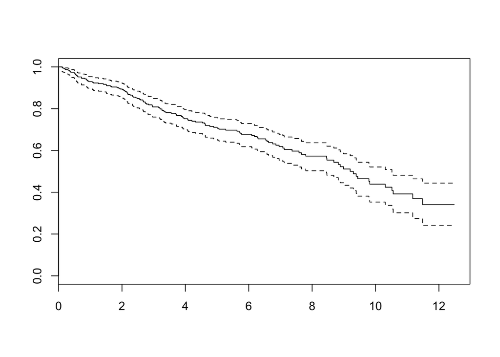

```r
# plot km curves
plot(km.overall)
```

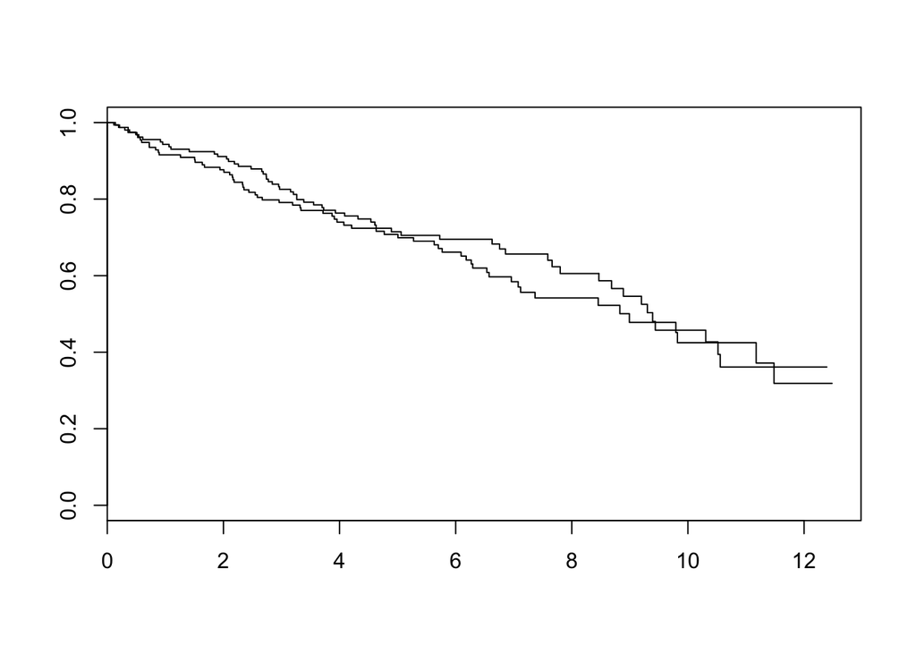

```r
plot(km.drug)
```

```r
# log rank test for equality of survivor functions
survdiff(SurvObj ~ drug, data=pbcData)
```

```
## Call:
## survdiff(formula = SurvObj ~ drug, data = pbcData)
##
##          N Observed Expected (O-E)^2/E (O-E)^2/V
## drug=0 154       60     61.8    0.0513     0.102
## drug=1 158       65     63.2    0.0502     0.102
##
##  Chisq= 0.1  on 1 degrees of freedom, p= 0.75
```

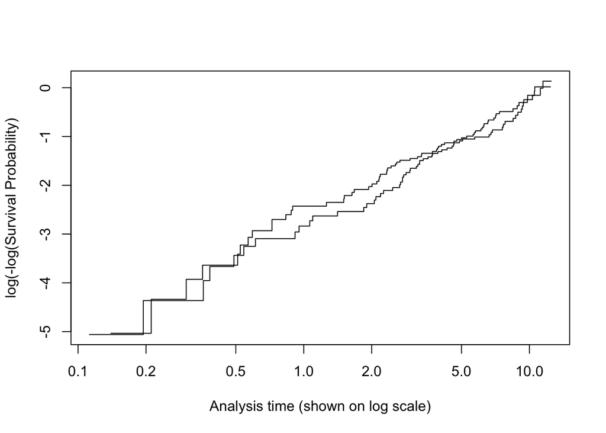

```r
# complimentary log-log plot
plot(km.drug, fun="cloglog", ylab="log(-log(Survival Probability)",
xlab="Analysis time (shown on log scale)")
```

4. Fit several Cox proportional hazards regression models to the ungrouped survival data:

```r
model1 = coxph(SurvObj ~ drug, data = pbcData)
summary(model1)
```

```
## Call:
## coxph(formula = SurvObj ~ drug, data = pbcData)
##
##   n= 312, number of events= 125
##
##         coef exp(coef) se(coef)     z Pr(>|z|)
## drug 0.05722   1.05889  0.17916 0.319    0.749
##
##      exp(coef) exp(-coef) lower .95 upper .95
## drug     1.059     0.9444    0.7453     1.504
##
## Concordance= 0.499  (se = 0.025 )
## Rsquare= 0   (max possible= 0.983 )
## Likelihood ratio test= 0.1  on 1 df,   p=0.7494
## Wald test            = 0.1  on 1 df,   p=0.7494
## Score (logrank) test = 0.1  on 1 df,   p=0.7494
```

```r
model2 = coxph(SurvObj ~ sex + bil + as.factor(histo), data = pbcData)
summary(model2)
```

```
## Call:
## coxph(formula = SurvObj ~ sex + bil + as.factor(histo), data = pbcData)
##
##   n= 312, number of events= 125
##
##                       coef exp(coef) se(coef)      z Pr(>|z|)
## sexMale            0.64275   1.90171  0.23926  2.686  0.00722 **
## bil                0.15149   1.16357  0.01424 10.637  < 2e-16 ***
## as.factor(histo)2  1.64339   5.17269  1.03376  1.590  0.11190
## as.factor(histo)3  2.03122   7.62340  1.01631  1.999  0.04565 *
## as.factor(histo)4  2.90689  18.29988  1.01216  2.872  0.00408 **
## ---
## Signif. codes:  0 '***' 0.001 '**' 0.01 '*' 0.05 '.' 0.1 ' ' 1
##
##                   exp(coef) exp(-coef) lower .95 upper .95
## sexMale               1.902    0.52584     1.190     3.040
## bil                   1.164    0.85943     1.132     1.197
## as.factor(histo)2     5.173    0.19332     0.682    39.233
## as.factor(histo)3     7.623    0.13118     1.040    55.877
## as.factor(histo)4    18.300    0.05465     2.517   133.045
##
## Concordance= 0.812  (se = 0.029 )
## Rsquare= 0.347   (max possible= 0.983 )
## Likelihood ratio test= 133.2  on 5 df,   p=0
## Wald test            = 149.2  on 5 df,   p=0
## Score (logrank) test = 218.8  on 5 df,   p=0
```

5. Save your R script file that documents and archives the steps of your statistical analysis. This file will make your analysis “reproducible.”
6. Summarize your findings in a brief report (less than two pages with at most one table and one figure) as if for a biomedical/public health journal. A suggested format is:
- Introduction – a few sentences about the research question(s)
- Data description – simple tabulations describing patient characteristics
- Results from multiple models that address question(s) (e.g., bivariate and multivariable)
- Graphical display that presents evidence in the data relevant to your scientific question.

## Introduction

The research question that I will try to answer in this report is whether D-penicillin (DPCA), the drug tested in the PBC trial, provided any benefit for the patient population as a whole (n=312) and for sub-groups based on sex, age and disease stage. I hypothesize that the drug effect will not be different between the 3 age categories, but will depend on disease stage. In other wrods, I expect that there will be differences in time to death between the 4 disease stages, specifically that more advanced disease will be more difficult to treat, which will result in a shorter time to event. I will also assess whether bilirubin is a prognostic marker and whether drug beenfit will differ among men versus women.

## Data description

The best way to describe the data in my opinion is using the `skim` function from the `skimr` R package. This function produces a table of descriptive statistics but also small histograms showing the distribution of each variable.

```r
# install.packages("skimr")
library(skimr)
skimr::skim(pbcData)
```

```
## Skim summary statistics
##  n obs: 312
##  n variables: 19
##
## Variable type: character
##  variable missing complete   n min max empty n_unique
##    agecat       0      312 312   8  11     0        3
##       sex       0      312 312   4   6     0        2
##   SurvObj       0      312 312  11  11     0      304
##
## Variable type: integer
##  variable missing complete   n   mean    sd p0   p25 median    p75 p100
##        _d       0      312 312   0.4   0.49  0  0       0     1       1
##       _st       0      312 312   1     0     1  1       1     1       1
##       _t0       0      312 312   0     0     0  0       0     0       0
##   agegr_2       0      312 312   0.32  0.47  0  0       0     1       1
##   agegr_3       0      312 312   0.34  0.47  0  0       0     1       1
##      case       0      312 312 156.5  90.21  1 78.75  156.5 234.25  312
##     death       0      312 312   0.4   0.49  0  0       0     1       1
##      drug       0      312 312   0.51  0.5   0  0       1     1       1
##     histo       0      312 312   3.03  0.88  1  2       3     4       4
##   hstage2       0      312 312   0.21  0.41  0  0       0     0       1
##   hstage3       0      312 312   0.38  0.49  0  0       0     1       1
##   hstage4       0      312 312   0.35  0.48  0  0       0     1       1
##      hist
##  ▇▁▁▁▁▁▁▆
##  ▁▁▁▇▁▁▁▁
##  ▁▁▁▇▁▁▁▁
##  ▇▁▁▁▁▁▁▃
##  ▇▁▁▁▁▁▁▅
##  ▇▇▇▇▇▇▇▇
##  ▇▁▁▁▁▁▁▆
##  ▇▁▁▁▁▁▁▇
##  ▁▁▅▁▁▇▁▇
##  ▇▁▁▁▁▁▁▂
##  ▇▁▁▁▁▁▁▅
##  ▇▁▁▁▁▁▁▅
##
## Variable type: numeric
##  variable missing complete   n  mean    sd    p0   p25 median   p75  p100
##        _t       0      312 312  5.5   3.08  0.11  3.26   5.04  7.39 12.48
##     ageyr       0      312 312 50.05 10.59 26.3  42.27  49.83 56.75 78.49
##       bil       0      312 312  3.26  4.53  0.3   0.8    1.35  3.43 28
##    survyr       0      312 312  5.5   3.08  0.11  3.26   5.04  7.39 12.48
##      hist
##  ▃▆▇▆▆▃▂▂
##  ▂▆▇▇▇▅▂▁
##  ▇▁▁▁▁▁▁▁
##  ▃▆▇▆▆▃▂▂
```

## Results

```r
model3 = coxph(SurvObj ~ sex + bil + as.factor(histo) + as.factor(agecat), data = pbcData)
summary(model3)
```

```
## Call:
## coxph(formula = SurvObj ~ sex + bil + as.factor(histo) + as.factor(agecat),
##     data = pbcData)
##
##   n= 312, number of events= 125
##
##                                  coef exp(coef) se(coef)      z Pr(>|z|)
## sexMale                       0.52988   1.69874  0.24311  2.180  0.02929
## bil                           0.15024   1.16211  0.01403 10.712  < 2e-16
## as.factor(histo)2             1.48565   4.41783  1.03534  1.435  0.15131
## as.factor(histo)3             1.86761   6.47278  1.01858  1.834  0.06672
## as.factor(histo)4             2.68780  14.69931  1.01467  2.649  0.00807
## as.factor(agecat)>= 55 yrs    0.55611   1.74388  0.24656  2.256  0.02410
## as.factor(agecat)45 - 55 yrs  0.39826   1.48924  0.24643  1.616  0.10607
##
## sexMale                      *
## bil                          ***
## as.factor(histo)2
## as.factor(histo)3            .
## as.factor(histo)4            **
## as.factor(agecat)>= 55 yrs   *
## as.factor(agecat)45 - 55 yrs
## ---
## Signif. codes:  0 '***' 0.001 '**' 0.01 '*' 0.05 '.' 0.1 ' ' 1
##
##                              exp(coef) exp(-coef) lower .95 upper .95
## sexMale                          1.699    0.58867    1.0548     2.736
## bil                              1.162    0.86050    1.1306     1.194
## as.factor(histo)2                4.418    0.22636    0.5807    33.612
## as.factor(histo)3                6.473    0.15449    0.8792    47.655
## as.factor(histo)4               14.699    0.06803    2.0119   107.395
## as.factor(agecat)>= 55 yrs       1.744    0.57343    1.0756     2.827
## as.factor(agecat)45 - 55 yrs     1.489    0.67148    0.9188     2.414
##
## Concordance= 0.82  (se = 0.029 )
## Rsquare= 0.359   (max possible= 0.983 )
## Likelihood ratio test= 138.6  on 7 df,   p=0
## Wald test            = 157.3  on 7 df,   p=0
## Score (logrank) test = 230.3  on 7 df,   p=0
```

```r
model3 = coxph(SurvObj ~ sex + bil + as.factor(histo) + as.factor(agecat), data = pbcData)
summary(model3)
```

```
## Call:
## coxph(formula = SurvObj ~ sex + bil + as.factor(histo) + as.factor(agecat),
##     data = pbcData)
##
##   n= 312, number of events= 125
##
##                                  coef exp(coef) se(coef)      z Pr(>|z|)
## sexMale                       0.52988   1.69874  0.24311  2.180  0.02929
## bil                           0.15024   1.16211  0.01403 10.712  < 2e-16
## as.factor(histo)2             1.48565   4.41783  1.03534  1.435  0.15131
## as.factor(histo)3             1.86761   6.47278  1.01858  1.834  0.06672
## as.factor(histo)4             2.68780  14.69931  1.01467  2.649  0.00807
## as.factor(agecat)>= 55 yrs    0.55611   1.74388  0.24656  2.256  0.02410
## as.factor(agecat)45 - 55 yrs  0.39826   1.48924  0.24643  1.616  0.10607
##
## sexMale                      *
## bil                          ***
## as.factor(histo)2
## as.factor(histo)3            .
## as.factor(histo)4            **
## as.factor(agecat)>= 55 yrs   *
## as.factor(agecat)45 - 55 yrs
## ---
## Signif. codes:  0 '***' 0.001 '**' 0.01 '*' 0.05 '.' 0.1 ' ' 1
##
##                              exp(coef) exp(-coef) lower .95 upper .95
## sexMale                          1.699    0.58867    1.0548     2.736
## bil                              1.162    0.86050    1.1306     1.194
## as.factor(histo)2                4.418    0.22636    0.5807    33.612
## as.factor(histo)3                6.473    0.15449    0.8792    47.655
## as.factor(histo)4               14.699    0.06803    2.0119   107.395
## as.factor(agecat)>= 55 yrs       1.744    0.57343    1.0756     2.827
## as.factor(agecat)45 - 55 yrs     1.489    0.67148    0.9188     2.414
##
## Concordance= 0.82  (se = 0.029 )
## Rsquare= 0.359   (max possible= 0.983 )
## Likelihood ratio test= 138.6  on 7 df,   p=0
## Wald test            = 157.3  on 7 df,   p=0
## Score (logrank) test = 230.3  on 7 df,   p=0
```

```r
library(dplyr)
# install.packages("broom")
library(broom)
pbcData %>%
    group_by(sex, drug) %>%
    summarise(med_surv = median(survyr))
```

```
## # A tibble: 4 x 3
## # Groups:   sex [?]
##   sex     drug med_surv
##   <chr>  <int>    <dbl>
## 1 Female     0     5.02
## 2 Female     1     5.33
## 3 Male       0     4.54
## 4 Male       1     3.57
```

```r
pbcData %>%
    group_by(agecat, drug) %>%
    summarise(med_surv = median(survyr))
```

```
## # A tibble: 6 x 3
## # Groups:   agecat [?]
##   agecat       drug med_surv
##   <chr>       <int>    <dbl>
## 1 < 45 yrs        0     5.67
## 2 < 45 yrs        1     5.31
## 3 >= 55 yrs       0     4.00
## 4 >= 55 yrs       1     4.84
## 5 45 - 55 yrs     0     5.87
## 6 45 - 55 yrs     1     5.63
```

```r
pbcData %>%
    group_by(histo, drug) %>%
    summarise(med_surv = median(survyr))
```

```
## # A tibble: 8 x 3
## # Groups:   histo [?]
##   histo  drug med_surv
##   <int> <int>    <dbl>
## 1     1     0    10.4
## 2     1     1     6.89
## 3     2     0     6.30
## 4     2     1     6.86
## 5     3     0     5.27
## 6     3     1     5.46
## 7     4     0     3.38
## 8     4     1     3.57
```

From this initial analysis it looks like patients in the highest age category that were given placebo fare the worst. These results indicate that elderly patients my stand to benefit the most from taking the drug. Shockingly, men taking the drug appear to have a shorter survival time than with the drug, and do not survive as long as a women in general. Similarly, the drug appeared to have a negative effect on survival in patients with earliest stage of disease (histo = 1). Now I will take a similar approach to the data but using a cox model.

```r
glance(model3)
```

```
##     n nevent statistic.log p.value.log statistic.sc p.value.sc
## 1 312    125      138.6393           0     230.2832          0
##   statistic.wald p.value.wald r.squared r.squared.max concordance
## 1         157.31            0 0.3587633     0.9834662   0.8198784
##   std.error.concordance    logLik      AIC      BIC
## 1            0.02851075 -570.6469 1155.294 1175.092
```

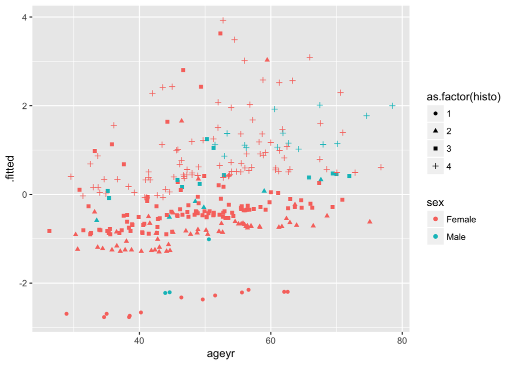

```r
aug <- augment(model3, pbcData)
risk_aug <- augment(model3, pbcData, type.predict = "risk")
exp_aug <- augment(model3, pbcData, type.predict = "expected")

par(mfrow=c(3,3))
## install.packages("ggplot2")
library(ggplot2)
ggplot(aug, aes(ageyr, .fitted, color = sex, shape = as.factor(histo))) + geom_point()
```

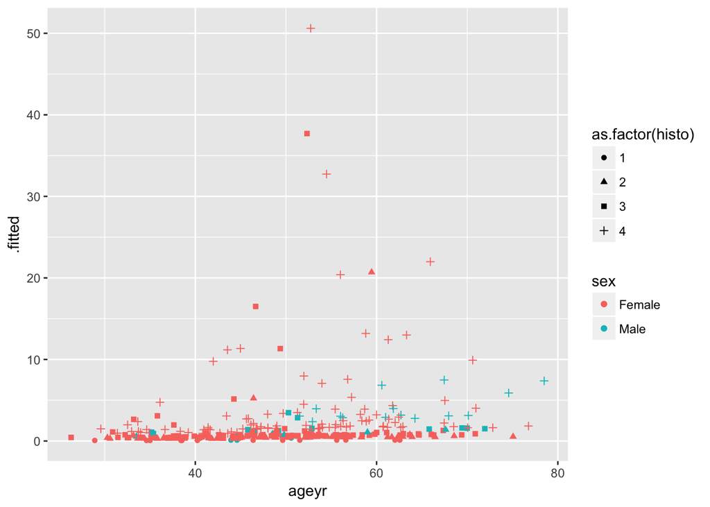

```r
ggplot(risk_aug, aes(ageyr, .fitted, color = sex, shape = as.factor(histo))) + geom_point()
```

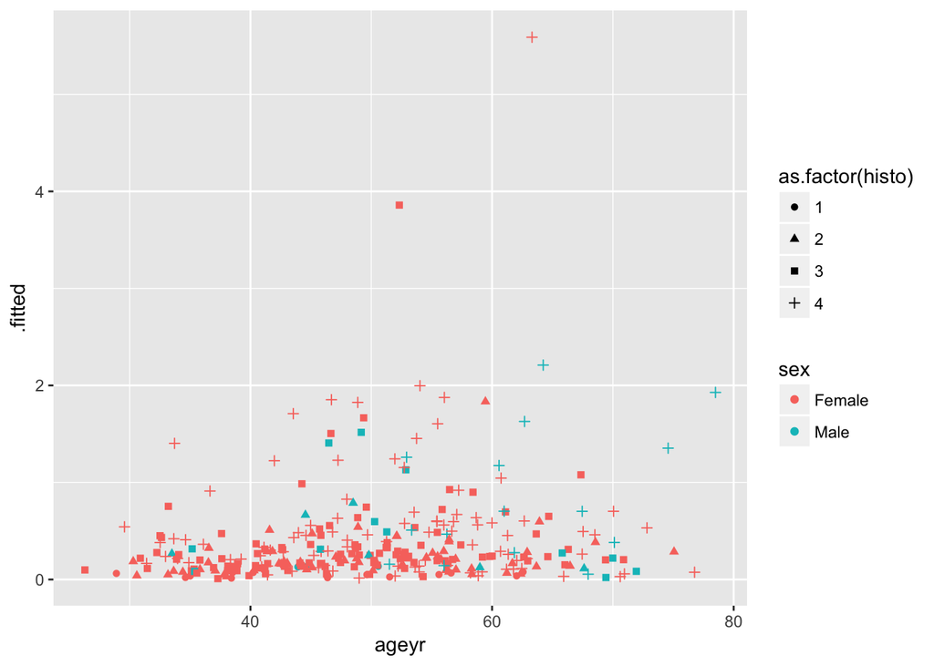

```r
ggplot(exp_aug, aes(ageyr, .fitted, color = sex, shape = as.factor(histo))) + geom_point()
```

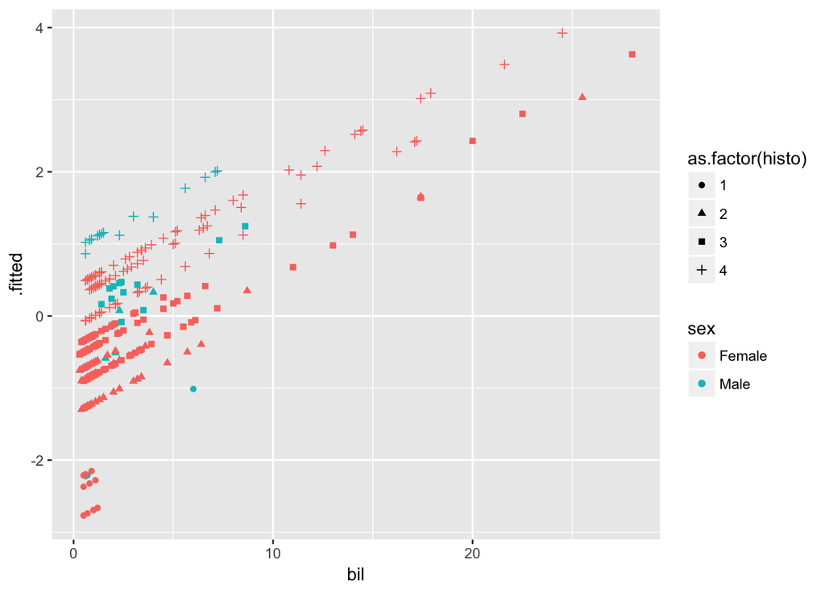

```r
ggplot(aug, aes(bil, .fitted, color = sex, shape = as.factor(histo))) + geom_point()
```

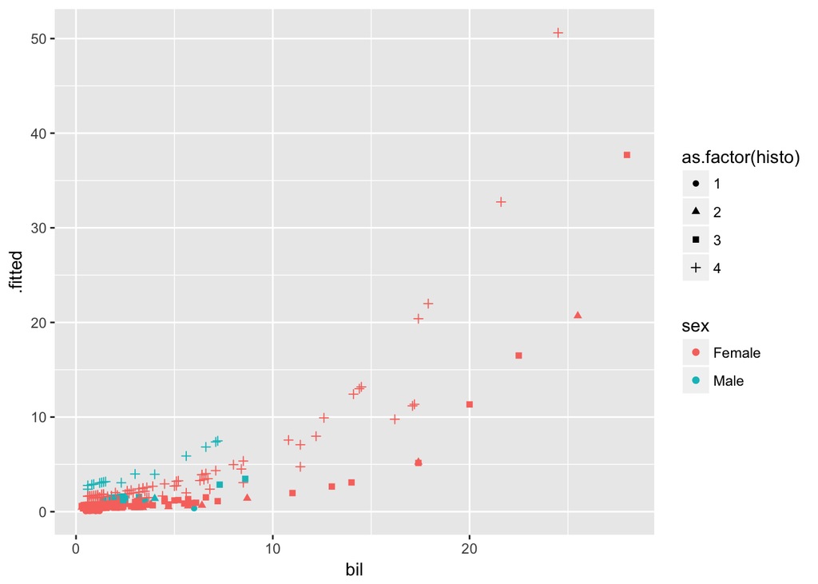

```r
ggplot(risk_aug, aes(bil, .fitted, color = sex, shape = as.factor(histo))) + geom_point()
```

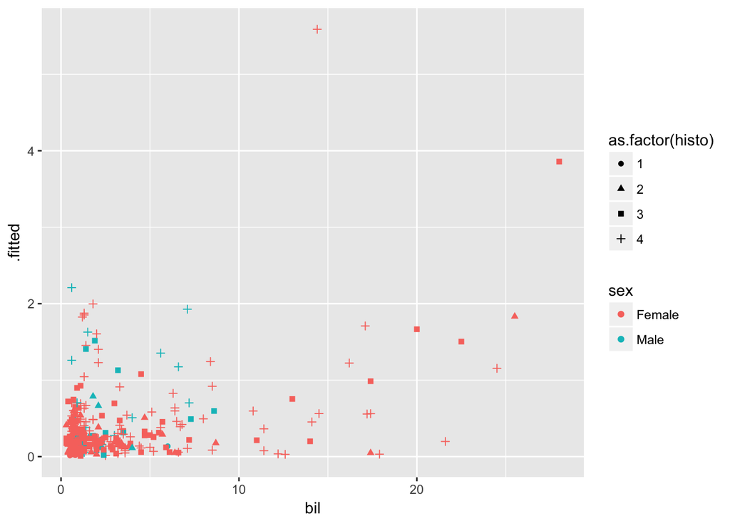

```r
ggplot(exp_aug, aes(bil, .fitted, color = sex, shape = as.factor(histo))) + geom_point()
```

## Graphical display

I plotted cox model fitted values against ageyr and bil variables marking sex and disease stage (`histo`) with color and different symbols, respectively.

## Conclusions

It is clear that all of the variables I picked are important in the final model although not all levels of the categorical variables were statistically significant. This work is only the beginning and more precise answers to the research questions discussed in the introduction will require further inspection with models more precisely adapted to each research question.